# Comparative Analysis of Female Lizard Lengths

Tommy King

### Introduction:

This report details and visualizes a comparative analysis of the total length of female Colorado Checkered Lizards and Desert Grassland Lizards. In order to explore this question, “the great debate”, as it was once dubbed by politicians around the world, we used mean comparison techniques such as t-tests and Cohen’s D to determine the effect size and significance of the differences in mean total length for the two species.

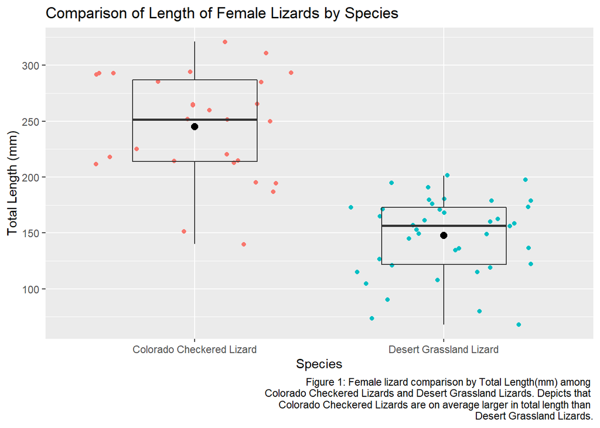

### Data Table of Female Lizard Statistics Comparison

Table 1: Lizard Length Statistic Comparison by Species: Total length (mm) mean, standard deviation, and sample size comparison for Female Colorado Checkered Lizards and Desert Grassland Lizards.

| Species | Mean Length (mm) | Standard Deviation Length (mm) | Sample Size |
| --- | --- | --- | --- |
| Colorado Checkered Lizard | 245 | 47 | 28 |
| Desert Grassland Lizard | 148 | 35 | 47 |

### Findings Interpretation:

On average, female Colorado Checkered Lizards have a larger total length in (mm) than female Desert Grassland Lizards (244.89 $\pm$ 47.32 and 147.6 $\pm$ 34.55 millimeters, respectively; mean $\pm$ 1 standard deviation). While the absolute difference in means is 97.29 mm (a 49.58% difference), the difference in means is significant (Welch’s two-sample t-test: t(46.43) = -9.28, p < 0.05), and the effect size is very large due to (Cohen’s *d* = -2.42). This indicates that we can be certain that female Colorado Checkered Lizards are larger in total length than female Desert Grassland Lizards.

### Data Citation:

Lightfoot, D. 2017. Lizard pitfall trap data (LTER-II, LTER-III) ver 36. Environmental Data Initiative. https://doi.org/10.6073/pasta/ff37b4cace16a9943575f3fd7067064e